# Airbnb: Tidying the Data

Tanya Bonilla

# Describe the source

This Airbnb dataset was downloaded from the site, Inside Airbnb, which provides “independent, non-commercial set of tools and data that allows you to explore how Airbnb is really being used in cities around the world.” The dataset originally had 48,864 listings before it was truncated down to 1,509 listings due to data restrictions. The reason why I chose Airbnb is because I am interested in seeing how much people are willing to spend on staying in other people’s homes and the effect it has had on hotels. There did not seem to be much limitations of the source beyond there being some missing varirables. The data was compiled and distributed 06 August, 2019.

First, we import tidyverse, tidyr, dplyr, and readr libraries, to import and tidy the data. In order to have clean data, we must omit any missing observations.

```r
suppressMessages(library(tidyverse))
suppressMessages(library(tidyr))
suppressMessages(library(dplyr))
suppressMessages(library(readr))
suppressMessages(library(ggplot2))

listings <- read_csv("https://raw.githubusercontent.com/tanyabonilla/portfolio/master/listings.csv", col_types = cols())
listings <-  na.omit(listings)
listings
```

| id | name | host_id | host_name | neighbourhood_group | neighbourhood | latitude | longitude | room_type | price | minimum_nights | number_of_reviews | last_review | reviews_per_month | calculated_host_listings_count | availability_365 |
| --- | --- | --- | --- | --- | --- | --- | --- | --- | --- | --- | --- | --- | --- | --- | --- |
| 2595 | Skylit Midtown Castle | 2845 | Jennifer | Manhattan | Midtown | 40.75362 | -73.98377 | Entire home/apt | 225 | 1 | 46 | 7/14/19 | 0.39 | 2 | 288 |
| 3831 | Cozy Entire Floor of Brownstone | 4869 | LisaRoxanne | Brooklyn | Clinton Hill | 40.68514 | -73.95976 | Entire home/apt | 89 | 1 | 274 | 7/26/19 | 4.64 | 1 | 212 |
| 5022 | Entire Apt: Spacious Studio/Loft by central park | 7192 | Laura | Manhattan | East Harlem | 40.79851 | -73.94399 | Entire home/apt | 80 | 10 | 9 | 11/19/18 | 0.10 | 1 | 0 |
| 5099 | Large Cozy 1 BR Apartment In Midtown East | 7322 | Chris | Manhattan | Murray Hill | 40.74767 | -73.97500 | Entire home/apt | 200 | 3 | 75 | 7/21/19 | 0.60 | 1 | 127 |
| 5121 | BlissArtsSpace! | 7356 | Garon | Brooklyn | Bedford-Stuyvesant | 40.68688 | -73.95596 | Private room | 60 | 45 | 49 | 10/5/17 | 0.39 | 1 | 0 |
| 5178 | Large Furnished Room Near B'way | 8967 | Shunichi | Manhattan | Hell's Kitchen | 40.76489 | -73.98493 | Private room | 79 | 2 | 434 | 7/13/19 | 3.48 | 1 | 239 |
| 5203 | Cozy Clean Guest Room - Family Apt | 7490 | MaryEllen | Manhattan | Upper West Side | 40.80178 | -73.96723 | Private room | 79 | 2 | 118 | 7/21/17 | 0.98 | 1 | 0 |
| 5222 | Best Hideaway | 7516 | Marilyn | Manhattan | East Village | 40.72764 | -73.97949 | Entire home/apt | 116 | 30 | 94 | 6/15/16 | 0.74 | 1 | 322 |
| 5238 | Cute & Cozy Lower East Side 1 bdrm | 7549 | Ben | Manhattan | Chinatown | 40.71344 | -73.99037 | Entire home/apt | 150 | 1 | 161 | 7/29/19 | 1.33 | 4 | 0 |
| 5295 | Beautiful 1br on Upper West Side | 7702 | Lena | Manhattan | Upper West Side | 40.80316 | -73.96545 | Entire home/apt | 135 | 5 | 53 | 6/22/19 | 0.42 | 1 | 1 |

[output cut: 1499 more lines]

## Tidying the Data

In order to get an idea on how much data we’re dealing with, we will display the number of columns and rows in the table.

```r
ncol(listings) #16 col
```

```
## [1] 16
```

```r
nrow(listings) #1509 rows
```

```
## [1] 1509
```

```r
colnames(listings)
```

```
##  [1] "id"                             "name"
##  [3] "host_id"                        "host_name"
##  [5] "neighbourhood_group"            "neighbourhood"
##  [7] "latitude"                       "longitude"
##  [9] "room_type"                      "price"
## [11] "minimum_nights"                 "number_of_reviews"
## [13] "last_review"                    "reviews_per_month"
## [15] "calculated_host_listings_count" "availability_365"
```

In order to have the data fit into Tidy Data’s criteria, we must split the dataset into 3 tables: Host, Reviews, and Listing.

Host contains the host’s id, host_name, and listings_count. Host_id is a discrete variable which contains a unqiue number that represents the host, host_name is a categorical variable, and listings_count is a discrete variable which houses the amount of listings a host has uploaded.

```r
host <- tibble (
  host_id = listings$host_id,
  host_name = listings$host_name,
  listings_count = listings$calculated_host_listings_count
)

host
```

| host_id | host_name | listings_count |
| --- | --- | --- |
| 2845 | Jennifer | 2 |
| 4869 | LisaRoxanne | 1 |
| 7192 | Laura | 1 |
| 7322 | Chris | 1 |
| 7356 | Garon | 1 |
| 8967 | Shunichi | 1 |
| 7490 | MaryEllen | 1 |
| 7516 | Marilyn | 1 |
| 7549 | Ben | 4 |
| 7702 | Lena | 1 |

[output cut: 1499 more lines]

The review table is going to contain the listing_id (continuous), the listing name (categorical), the number of reviews (discrete), the date of the last review (continuous), and the reviews per month (discrete).

```r
reviews <- tibble (
  listing_id = listings$id,
  name = listings$name,
  number_of_reviews = listings$number_of_reviews,
  date_last_review = listings$last_review,
  reviews_per_month = listings$reviews_per_month
)

reviews
```

| listing_id | name | number_of_reviews | date_last_review | reviews_per_month |
| --- | --- | --- | --- | --- |
| 2595 | Skylit Midtown Castle | 46 | 7/14/19 | 0.39 |
| 3831 | Cozy Entire Floor of Brownstone | 274 | 7/26/19 | 4.64 |
| 5022 | Entire Apt: Spacious Studio/Loft by central park | 9 | 11/19/18 | 0.10 |
| 5099 | Large Cozy 1 BR Apartment In Midtown East | 75 | 7/21/19 | 0.60 |
| 5121 | BlissArtsSpace! | 49 | 10/5/17 | 0.39 |
| 5178 | Large Furnished Room Near B'way | 434 | 7/13/19 | 3.48 |
| 5203 | Cozy Clean Guest Room - Family Apt | 118 | 7/21/17 | 0.98 |
| 5222 | Best Hideaway | 94 | 6/15/16 | 0.74 |
| 5238 | Cute & Cozy Lower East Side 1 bdrm | 161 | 7/29/19 | 1.33 |
| 5295 | Beautiful 1br on Upper West Side | 53 | 6/22/19 | 0.42 |

[output cut: 1499 more lines]

The listing table contains the listing_id (discrete), name (categorical), price of the listing (discrete), neighbourhood_group (categorical), neighbourhood (categorical), latitude (continuous), longitude (continuous), room_type (categorical), and the minimum amount of nights a guest can stay (discrete). After we create the table we are going to change neighbourhood_group, neighbourhood, and room_type to factors. By creating a graph, we can see that the neighbourhood with the most listings are Brooklyn and Manhatten.

```r
listing <- tibble (
  listing_id = listings$id,
  name = listings$name,
  price = listings$price,
  neighbourhood_group = listings$neighbourhood_group,
  neighbourhood = listings$neighbourhood,
  latitude = listings$latitude,
  longitude = listings$longitude,
  room_type = listings$room_type,
  minimum_nights = listings$minimum_nights
)
listing$neighbourhood_group <- as.factor(listing$neighbourhood_group)
listing$neighbourhood <- as_factor(listing$neighbourhood)
listing$room_type <- as_factor(listing$room_type)
levels(listing$neighbourhood_group)
```

```
## [1] "Bronx"         "Brooklyn"      "Manhattan"     "Queens"
## [5] "Staten Island"
```

```r
levels(listing$neighbourhood)
```

```
##   [1] "Midtown"                   "Clinton Hill"
##   [3] "East Harlem"               "Murray Hill"
##   [5] "Bedford-Stuyvesant"        "Hell's Kitchen"
##   [7] "Upper West Side"           "East Village"
##   [9] "Chinatown"                 "South Slope"
##  [11] "West Village"              "Williamsburg"
##  [13] "Fort Greene"               "Chelsea"
##  [15] "Crown Heights"             "Park Slope"
##  [17] "Windsor Terrace"           "Harlem"
##  [19] "Greenpoint"                "Bushwick"
##  [21] "Lower East Side"           "Prospect-Lefferts Gardens"
##  [23] "Long Island City"          "Kips Bay"
##  [25] "SoHo"                      "Upper East Side"
##  [27] "Red Hook"                  "Prospect Heights"
##  [29] "Washington Heights"        "Woodside"
```

[output cut: 41 more lines]

```r
levels(listing$room_type)
```

```
## [1] "Entire home/apt" "Private room"    "Shared room"
```

```r
listing
```

| listing_id | name | price | neighbourhood_group | neighbourhood | latitude | longitude | room_type | minimum_nights |
| --- | --- | --- | --- | --- | --- | --- | --- | --- |
| 2595 | Skylit Midtown Castle | 225 | Manhattan | Midtown | 40.75362 | -73.98377 | Entire home/apt | 1 |
| 3831 | Cozy Entire Floor of Brownstone | 89 | Brooklyn | Clinton Hill | 40.68514 | -73.95976 | Entire home/apt | 1 |
| 5022 | Entire Apt: Spacious Studio/Loft by central park | 80 | Manhattan | East Harlem | 40.79851 | -73.94399 | Entire home/apt | 10 |
| 5099 | Large Cozy 1 BR Apartment In Midtown East | 200 | Manhattan | Murray Hill | 40.74767 | -73.97500 | Entire home/apt | 3 |
| 5121 | BlissArtsSpace! | 60 | Brooklyn | Bedford-Stuyvesant | 40.68688 | -73.95596 | Private room | 45 |
| 5178 | Large Furnished Room Near B'way | 79 | Manhattan | Hell's Kitchen | 40.76489 | -73.98493 | Private room | 2 |
| 5203 | Cozy Clean Guest Room - Family Apt | 79 | Manhattan | Upper West Side | 40.80178 | -73.96723 | Private room | 2 |
| 5222 | Best Hideaway | 116 | Manhattan | East Village | 40.72764 | -73.97949 | Entire home/apt | 30 |
| 5238 | Cute & Cozy Lower East Side 1 bdrm | 150 | Manhattan | Chinatown | 40.71344 | -73.99037 | Entire home/apt | 1 |
| 5295 | Beautiful 1br on Upper West Side | 135 | Manhattan | Upper West Side | 40.80316 | -73.96545 | Entire home/apt | 5 |

[output cut: 1499 more lines]

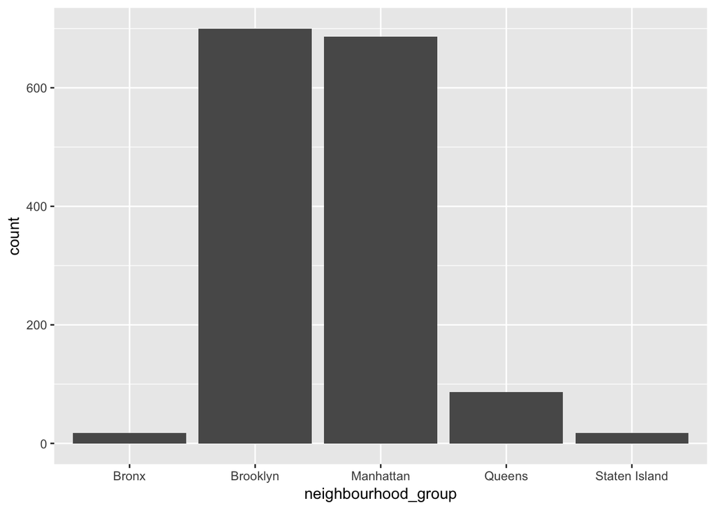

```r
ggplot(listing, aes(x = neighbourhood_group)) + geom_bar()
```

# Research Questions

1. What types of neighbourhood receive the most reviews?
2. Do the prices of the type of rooms have any effect on the reviews?
3. Does the frequency of the host’s listings affect the price of the room?
4. Is there a relationship or any kind between the name of the listing and the availability throughout the year?
5. How do the amount of room affect price of a listing?